# Computational results (preliminary version)

This report is a preliminary version of the computational results included in the paper

Nicolas Forget http://pure.au.dk/portal/en/nforget@econ.au.dk (CORAL, BSS, Aarhus University)https://econ.au.dk/coral , Lars Relund Nielsen http://pure.au.dk/portal/en/larsrn@econ.au.dk (CORAL, BSS, Aarhus University)https://econ.au.dk/coral , Sune Lauth Gadegaard http://pure.au.dk/portal/en/sgadegaard@econ.au.dk (CORAL, BSS, Aarhus University)https://econ.au.dk/coral  
2020-06-19

### Table of Contents

[*This report is a preliminary version of the computational results included in the paper. Only instances generated with option spheredown are used since they are hard instances.*]

[See https://rstudio.github.io/distill/ on how to write this report.]

All instances are minimized, i.e. if an objective function $z(x)$ is maximized, we minimize $-z(x)$ instead. Note that in all instances only binary variables are considered.

In this section we report on the computational experiments conducted with the tri–objective branch–and–bound algorithm. All algorithms have been implemented in Julia $1.0.1$. The experiments have been done on a computer with an Intel(R) Core(TM) i7-8700 CPU @ 3.20GHz processor and 32GB of RAM memory [check if correct].

The algorithm can be run using *algorithm configuration* parameters `nS`, `vS`, `oB` and `eps` where

[Add other implementation details, e.g. about Bensolve and possible numerical instabilities]

The purpose of the computational study is to answer the following questions:

[Just some ideas for the moment. Add/modify as you like]

1. What is the performance of the different algorithm configurations?
2. Which algorithm configurations perform the best?
3. Is it worth doing objective branching?
4. How do node selection, variable selection and objective branching affect the performance of the algorithm?
5. In which subprocedures are the cpu time used?
6. How are nodes pruned?
7. Where in the tree do we use obj branching avg + min and max values (relative values and box plot)?
8. Depth of tree in AP vs KP?
9. Do integer rounding improve the performance?
10. How is the performance of the tri-objective B&B algorithm compared to objective branching algorithms? Statistic: Number of nodes in the tree relative to total possible given depth Plot reverse profiles (y = %, x = n)

# Test instances

Table 1: Instances used.

| n[^1] | # | range | gapO | ratio |
| --- | --- | --- | --- | --- |
| **AP** |  |  |  |  |
| 36 | 10 | [1,1000] | 3303 | 0.93 |
| 49 | 10 | [1,1000] | 4056 | 0.95 |
| 64 | 10 | [1,1000] | 4778 | 0.91 |
| **KP** |  |  |  |  |
| 10 | 30 | [1,1000] | 1802 | 0.99 |
| 15 | 30 | [1,1000] | 2850 | 0.98 |
| 25 | 30 | [1,1000] | 4592 | 0.95 |
| 30 | 1 | [1,1000] | 5203 | 0.90 |
| **UFLP** |  |  |  |  |
| 30 | 10 | [1,1000]\|[1,100] | 2993 | 0.19 |
| 42 | 10 | [1,1000]\|[1,100] | 3752 | 0.17 |
| 56 | 1 | [1,1000]\|[1,100] | 4729 | 0.14 |

# Output statistics

# What is the performance of the different algorithm configurations?

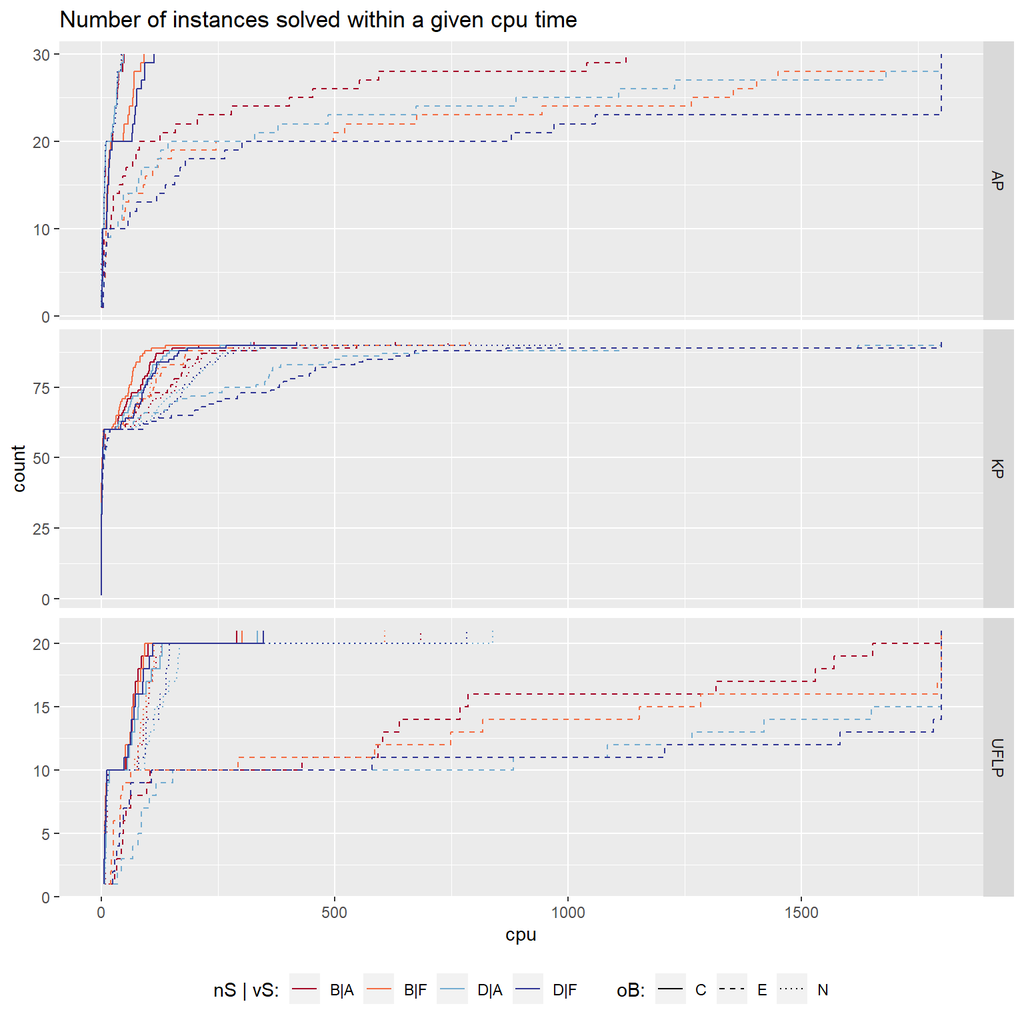

Figure 1: Performance plots for the different problem classes

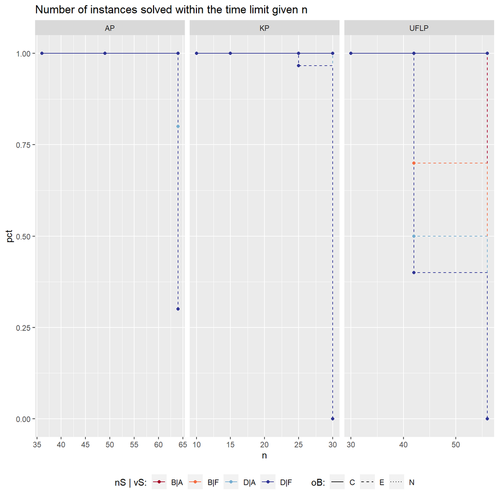

Figure 2: Reverse performance plots for the different problem classes

A performance plot for the different algorithm configurations are given in Figure 1. Reverse performance plot for the different algorithm configurations are given in Figure 2.

[Explain results and drop ‘OB = exact’ alg configs in the remaining]

# Which algorithm configurations perform the best?

Table 2: Results for each instance group.

| n | YN (se, sne, us) | D\|A\|N cpu | D\|A\|N nodes (d leaf) | D\|A\|N prune (I/O/D) | B\|F\|N cpu | B\|F\|N nodes (d leaf) | B\|F\|N prune (I/O/D) | D\|F\|N cpu | D\|F\|N nodes (d leaf) | D\|F\|N prune (I/O/D) | B\|A\|N cpu | B\|A\|N nodes (d leaf) | B\|A\|N prune (I/O/D) | D\|A\|C cpu | D\|A\|C nodes (d leaf) | D\|A\|C prune (I/O/D) | B\|F\|C cpu | B\|F\|C nodes (d leaf) | B\|F\|C prune (I/O/D) | D\|F\|C cpu | D\|F\|C nodes (d leaf) | D\|F\|C prune (I/O/D) | B\|A\|C cpu | B\|A\|C nodes (d leaf) | B\|A\|C prune (I/O/D) | B\|A\|E cpu | B\|A\|E nodes (d leaf) | B\|A\|E prune (I/O/D) | B\|F\|E cpu | … |
| --- | --- | --- | --- | --- | --- | --- | --- | --- | --- | --- | --- | --- | --- | --- | --- | --- | --- | --- | --- | --- | --- | --- | --- | --- | --- | --- | --- | --- | --- | --- |
| **AP** |  |  |  |  |  |  |  |  |  |  |  |  |  |  |  |  |  |  |  |  |  |  |  |  |  |  |  |  |  | … |
| 36 | 160 (14/0/86) | 1.4 [1.1,1.6] | 828 [6,11,16] | [0,75,25] | 1.4 [1.1,1.7] | 807 [6,11,16] | [0,74,26] | 1.4 [1.1,1.6] | 831 [6,11,16] | [0,76,24] | 1.4 [1.1,1.7] | 804 [6,11,16] | [0,73,27] | 1.6 [1.2,2] | 1021 [6,11,16] | [76,18,6] | 2.8 [1.9,3.5] | 1540 [3,18,27] | [83,11,6] | 3 [2.1,3.7] | 1783 [3,19,27] | [83,12,5] | 1.7 [1.3,2] | 987 [6,11,16] | [76,17,7] | 5.6 [3.1,11.1] | 2374 [6,10,16] | [92,5,3] | 7.8 [3.5,11.2] | … |
| 49 | 348 (8/0/92) | 7.7 [6,10] | 2840 [7,13,21] | [0,61,39] | 7.8 [6,10] | 2573 [7,13,20] | [0,59,41] | 7.6 [6,9.8] | 2847 [7,13,21] | [0,62,38] | 7.8 [5.8,10] | 2563 [7,13,21] | [0,58,42] | 7.8 [6.1,10.4] | 3321 [7,13,21] | [76,14,10] | 14.9 [11.4,21.4] | 4933 [3,25,38] | [82,8,11] | 16.1 [12.3,23.4] | 6170 [3,26,38] | [83,9,8] | 8 [6.3,10.9] | 2965 [7,13,21] | [77,13,11] | 45.8 [20.9,81.5] | 8924 [6,12,20] | [92,3,4] | 101.2 [35.9,246.8] | … |
| 64 | 741 (5/0/95) | 33.8 [23.2,42.9] | 8509 [8,15,26] | [0,51,49] | 34.5 [24.8,44.8] | 7414 [8,15,26] | [0,47,53] | 34 [23.4,43.5] | 8558 [8,15,27] | [0,51,49] | 34.4 [24.5,45] | 7379 [8,15,26] | [0,47,53] | 33.4 [22,48.3] | 9640 [8,15,23] | [77,11,12] | 67.2 [47.5,92.5] | 13811 [3,30,52] | [79,6,15] | 82.3 [66.8,114] | 20584 [3,33,53] | [82,7,11] | 34.5 [24.8,48.8] | 8274 [8,14,24] | [76,10,14] | 494.4 [126.7,1124.8] | 33983 [6,13,22] | [93,2,5] | 1171.6* [498,1800] | … |
| **KP** |  |  |  |  |  |  |  |  |  |  |  |  |  |  |  |  |  |  |  |  |  |  |  |  |  |  |  |  |  | … |
| 10 | 43 (28/0/72) | 0.3 [0.1,0.4] | 509 [6,10,11] | [38,40,22] | 0.2 [0.1,0.3] | 336 [5,9,11] | [28,46,26] | 0.2 [0.1,0.3] | 393 [5,9,11] | [33,49,18] | 0.3 [0.1,0.4] | 483 [6,9,11] | [35,39,26] | 0.2 [0.1,0.4] | 474 [6,9,11] | [75,21,4] | 0.2 [0.1,0.3] | 315 [5,9,11] | [63,28,8] | 0.2 [0.1,0.4] | 371 [5,9,11] | [64,32,4] | 0.2 [0.1,0.4] | 456 [6,9,11] | [72,21,7] | 0.3 [0.1,0.5] | 476 [6,9,11] | [75,19,6] | 0.2 [0.1,0.4] | … |
| 15 | 145 (16/0/84) | 4 [1.3,7.1] | 4333 [7,13,16] | [29,28,43] | 2.9 [1.3,5] | 2499 [7,13,16] | [12,43,45] | 3.4 [1.9,5.7] | 3540 [7,13,16] | [19,46,35] | 3.8 [1.3,7.2] | 3849 [7,13,16] | [24,26,50] | 3.4 [1,7.2] | 3796 [7,13,16] | [79,12,9] | 2.4 [0.9,5.5] | 2238 [7,12,16] | [67,19,14] | 3.2 [1.5,7.1] | 3117 [7,13,16] | [70,21,9] | 3.2 [1,7.4] | 3416 [8,13,16] | [76,11,13] | 4.6 [1.3,11] | 4014 [7,12,16] | [83,8,9] | 3.7 [1.3,9.2] | … |
| 25 | 564 (8/0/92) | 185.2 [67.1,464.8] | 70216 [8,20,26] | [18,16,66] | 104.7 [46.4,184.8] | 28759 [7,19,26] | [3,41,56] | 189.8 [82.2,410.4] | 71319 [7,20,26] | [6,44,50] | 156.3 [60,358.4] | 44454 [8,19,26] | [12,16,72] | 94.2 [32.8,255.7] | 56343 [9,18,26] | [83,4,13] | 60.8 [23.5,137.7] | 22963 [7,18,26] | [70,9,20] | 104.4 [41.6,267.2] | 53473 [8,19,26] | [75,10,15] | 83.1 [30.9,209.9] | 35986 [9,17,26] | [79,4,18] | 149.8 [47,547.3] | 54749 [7,16,26] | [89,2,10] | 117.1 [38.1,288.4] | … |
| 30 | 1071 (5/0/95) | 895.7 [895.7,895.7] | 203075 [9,23,31] | [15,18,66] | 678.8 [678.8,678.8] | 92331 [8,22,31] | [2,44,54] | 983.6 [983.6,983.6] | 225475 [9,23,31] | [3,48,49] | 743.5 [743.5,743.5] | 118887 [9,22,31] | [8,21,70] | 321 [321,321] | 154733 [10,21,31] | [82,3,15] | 320.8 [320.8,320.8] | 65949 [8,20,31] | [67,7,25] | 418.6 [418.6,418.6] | 150101 [9,22,31] | [73,8,19] | 327.3 [327.3,327.3] | 93851 [9,20,31] | [78,3,19] | 630.6 [630.6,630.6] | 148547 [6,18,31] | [88,1,10] | 788.9 [788.9,788.9] | … |
| **UFLP** |  |  |  |  |  |  |  |  |  |  |  |  |  |  |  |  |  |  |  |  |  |  |  |  |  |  |  |  |  | … |
| 30 | 325 (14/0/86) | 11.2 [7.2,15.8] | 5010 [7,14,23] | [0,68,32] | 9.4 [5.9,14.5] | 3517 [7,14,21] | [0,65,35] | 9.4 [6.8,15.3] | 4270 [7,14,22] | [0,70,30] | 11.2 [7.3,15.3] | 3950 [7,13,22] | [0,62,38] | 10.5 [6.8,17.2] | 5216 [7,14,21] | [76,16,8] | 8.4 [6.2,12.4] | 3157 [3,19,26] | [75,16,9] | 8.9 [6.1,12.3] | 3868 [3,20,26] | [75,18,7] | 9.9 [5.9,18.1] | 4033 [7,13,21] | [77,13,10] | 53.9 [17,105.3] | 10512 [6,11,19] | [93,3,4] | 33.4 [18.3,64.1] | … |
| 42 | 998 (8/0/92) | 129.4 [93.2,168.1] | 29426 [8,18,31] | [0,57,43] | 94.7 [72.1,113.8] | 17321 [7,17,31] | [0,51,49] | 119 [80.3,146.3] | 27599 [7,18,32] | [0,57,43] | 99.8 [78.4,129.7] | 18056 [8,17,30] | [0,51,49] | 87.7 [56.6,130.9] | 26849 [8,17,28] | [77,12,11] | 71.8 [50.7,94.2] | 14976 [4,25,39] | [76,10,14] | 77.5 [48.9,110.9] | 20581 [4,26,39] | [77,13,10] | 72 [54.3,101.2] | 16420 [9,15,26] | [77,9,14] | 989.5 [430,1654] | 56143 [6,13,24] | [93,2,5] | 1207.7* [293.1,1800] | … |
| 56 | 1970 (7/0/93) | 839.8 [839.8,839.8] | 93939 [9,21,48] | [0,46,54] | 608.2 [608.2,608.2] | 51547 [7,20,42] | [0,42,58] | 784.1 [784.1,784.1] | 90775 [7,21,46] | [0,50,50] | 685.5 [685.5,685.5] | 56593 [9,20,43] | [0,40,60] | 334.6 [334.6,334.6] | 69731 [9,18,33] | [78,10,12] | 302.2 [302.2,302.2] | 39587 [4,29,53] | [75,7,17] | 347.4 [347.4,347.4] | 63317 [4,31,52] | [78,9,12] | 290.6 [290.6,290.6] | 41263 [9,17,33] | [77,8,16] | 1800* [1800,1800] | 18694 [6,10,11] | [85,0,15] | 1800* [1800,1800] | … |

[Discussion based on a table where drop the exact columns, I have added some statistics here that we may drop later.]

[What more need to be included in the table?]

# ToDo

Based on the above:

- Generate harder instances until hit the time limit of 30 min.
- Should we generate multi-dim KP also?
- Research questions and sequence?

[OLD STUFF to be removed.]

# Numerical instabilities

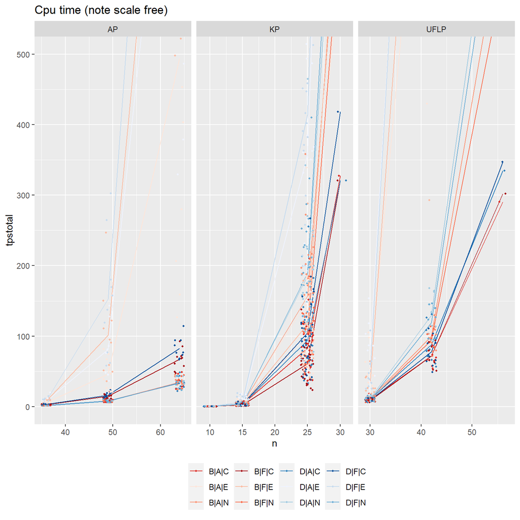

# Detailed results for each instance

- Instances with lowest number of nondominated points: Forget20-KP_10_3_1-1000_spheredown_1_10, Forget20-KP_10_3_1-1000_spheredown_2_10, Forget20-KP_10_3_1-1000_spheredown_2_2
- Instances with highest number of nondominated points (solved): Forget20-UFLP_6_3_1-1000_1-100_spheredown_1_3, Forget20-UFLP_6_3_1-1000_1-100_spheredown_1_8, Forget20-UFLP_7_3_1-1000_1-100_spheredown_1_1
- Instances with lowest unsupported nondominated points percentage: Forget20-KP_10_3_1-1000_spheredown_2_10, Forget20-KP_10_3_1-1000_spheredown_2_2, Forget20-KP_10_3_1-1000_spheredown_2_8
- Instances with highest unsupported nondominated points percentage: Forget20-AP_8_3_1-1000_spheredown_1_10, Forget20-AP_8_3_1-1000_spheredown_1_2, Forget20-AP_8_3_1-1000_spheredown_1_3
- Instances with highest supported non-extreme nondominated points percentage: Forget20-AP_6_3_1-1000_spheredown_1_1, Forget20-AP_6_3_1-1000_spheredown_1_10, Forget20-AP_6_3_1-1000_spheredown_1_2
- Instances with highest variance in cpu time: Forget20-UFLP_6_3_1-1000_1-100_spheredown_1_10, Forget20-UFLP_6_3_1-1000_1-100_spheredown_1_3, Forget20-UFLP_6_3_1-1000_1-100_spheredown_1_8
[^1]: tst